# Check Interaction

## Load Data

Load necessary data.

```r
set.seed(888)
source('~/MRC_BSU_Internship_LDL/Recursive_Partitioning/ExtractSubsample.R')
#Read in genotype and phenotype, indep set of interaction variants
data <- readRDS('~/bsu_scratch/LDL_Project_Data_Aug2019/Random_Forest/rs12916_rs17238484_rs5909_rs2303152_rs10066707_rs2006760_LDLdirect/data_p_9e-06_maf_5e-2.rds')
testingSet <- readRDS('~/bsu_scratch/LDL_Project_Data_Aug2019/Genotype_Data/test_set.rds')
trainingSet <- readRDS('~/bsu_scratch/LDL_Project_Data_Aug2019/Genotype_Data/training_set.rds')

#Obtain top snp
interactionData <- data.table::fread('~/bsu_scratch/LDL_Project_Data_Aug2019/Interaction_Data/HMGCR_LDL_known.txt')
topSNP <- dplyr::filter(interactionData,rsid %in% colnames(data$dosageMatrix))
topSNP <- topSNP$rsid[which.min(topSNP$p_int)]
```

## Training Set Interactions

We check manually whether the p-value of the strongest interacting SNP match what was calculated.

```r
#Training set interaction effect
summary(lm(formula = 'LDL ~ HMGCR*topSNP + sex + ages + bmi + PC1 + PC2 +PC3 + PC4 + PC5',data = cbind(data.frame(LDL = data$phenotypes[trainingSet],HMGCR = data$dosageTarget[trainingSet],topSNP = data$dosageMatrix[trainingSet,topSNP]),data$covariates[trainingSet,])))
```

```
##
## Call:
## lm(formula = "LDL ~ HMGCR*topSNP + sex + ages + bmi + PC1 + PC2 +PC3 + PC4 + PC5",
##     data = cbind(data.frame(LDL = data$phenotypes[trainingSet],
##         HMGCR = data$dosageTarget[trainingSet], topSNP = data$dosageMatrix[trainingSet,
##             topSNP]), data$covariates[trainingSet, ]))
##
## Residuals:
##     Min      1Q  Median      3Q     Max
## -3.5438 -0.5660 -0.0544  0.5047  8.2660
##
## Coefficients:
##                Estimate Std. Error t value Pr(>|t|)
## (Intercept)   2.7829875  0.0171623 162.157  < 2e-16 ***
## HMGCR        -0.3820950  0.0177533 -21.522  < 2e-16 ***
## topSNP       -0.0581584  0.0127238  -4.571 4.86e-06 ***
## sex          -0.0991504  0.0034393 -28.829  < 2e-16 ***
## ages          0.0125627  0.0002135  58.833  < 2e-16 ***
## bmi           0.0144541  0.0003615  39.984  < 2e-16 ***
## PC1           0.5674439  0.1012537   5.604 2.09e-08 ***
## PC2           0.4648631  0.1205796   3.855 0.000116 ***
## PC3           0.3979816  0.1637550   2.430 0.015085 *
## PC4           0.1582651  0.1898589   0.834 0.404511
## PC5          -0.1039104  0.1944323  -0.534 0.593045
## HMGCR:topSNP  0.1391195  0.0288157   4.828 1.38e-06 ***
## ---
## Signif. codes:  0 '***' 0.001 '**' 0.01 '*' 0.05 '.' 0.1 ' ' 1
##
## Residual standard error: 0.8227 on 232407 degrees of freedom
## Multiple R-squared:  0.02696,    Adjusted R-squared:  0.02691
## F-statistic: 585.4 on 11 and 232407 DF,  p-value: < 2.2e-16
```

## Testing Set Interactions

```r
#Testing set interactions effect
summary(lm(formula = 'LDL ~ HMGCR*topSNP + sex + ages + bmi + PC1 + PC2 +PC3 + PC4 + PC5',data = cbind(data.frame(LDL = data$phenotypes[testingSet],HMGCR = data$dosageTarget[testingSet],topSNP = data$dosageMatrix[testingSet,topSNP]),data$covariates[testingSet,])))
```

```
##
## Call:
## lm(formula = "LDL ~ HMGCR*topSNP + sex + ages + bmi + PC1 + PC2 +PC3 + PC4 + PC5",
##     data = cbind(data.frame(LDL = data$phenotypes[testingSet],
##         HMGCR = data$dosageTarget[testingSet], topSNP = data$dosageMatrix[testingSet,
##             topSNP]), data$covariates[testingSet, ]))
##
## Residuals:
##     Min      1Q  Median      3Q     Max
## -3.3134 -0.5656 -0.0544  0.5025  5.9842
##
## Coefficients:
##                Estimate Std. Error t value Pr(>|t|)
## (Intercept)   2.7306974  0.0242639 112.542  < 2e-16 ***
## HMGCR        -0.2997272  0.0250480 -11.966  < 2e-16 ***
## topSNP        0.0380228  0.0180091   2.111  0.03475 *
## sex          -0.0965033  0.0048611 -19.852  < 2e-16 ***
## ages          0.0126818  0.0003022  41.963  < 2e-16 ***
## bmi           0.0147237  0.0005092  28.913  < 2e-16 ***
## PC1           0.5147518  0.1436837   3.583  0.00034 ***
## PC2           0.1351820  0.1710970   0.790  0.42948
## PC3          -0.2089147  0.2296577  -0.910  0.36299
## PC4           0.0383710  0.2697698   0.142  0.88689
## PC5           0.0555513  0.2714770   0.205  0.83786
## HMGCR:topSNP -0.0653328  0.0407218  -1.604  0.10863
## ---
## Signif. codes:  0 '***' 0.001 '**' 0.01 '*' 0.05 '.' 0.1 ' ' 1
##
## Residual standard error: 0.8221 on 116198 degrees of freedom
## Multiple R-squared:  0.02731,    Adjusted R-squared:  0.02722
## F-statistic: 296.6 on 11 and 116198 DF,  p-value: < 2.2e-16
```

## Divide Testing Set Based on Top Interacting SNP

We divide the testing set to reprsent a 2 node tree, based on the top SNP. A node is the homozygous reference group and another node is homozygous alternative/heterozygous.

```r
#Segregate samples based on alelles of top SNP
trainingSetData <- ExtractSubSample(data,trainingSet,testingSet)$outofbag
homoRef <- trainingSetData$dosageMatrix[,topSNP]==0
homoRefFit <- summary(lm(formula = 'LDL ~ HMGCR + sex + ages + bmi + PC1 + PC2 +PC3 + PC4 + PC5',data = cbind(data.frame(LDL = trainingSetData$phenotypes[homoRef],HMGCR = trainingSetData$dosageTarget[homoRef]),trainingSetData$covariates[homoRef,])))
nonHomoRefFit <- summary(lm(formula = 'LDL ~ HMGCR + sex + ages + bmi + PC1 + PC2 +PC3 + PC4 + PC5',data = cbind(data.frame(LDL = trainingSetData$phenotypes[!homoRef],HMGCR = trainingSetData$dosageTarget[!homoRef]),trainingSetData$covariates[!homoRef,])))
```

We check the difference of HMGCR score between the two group.

```r
homoRefFit
```

```
##
## Call:
## lm(formula = "LDL ~ HMGCR + sex + ages + bmi + PC1 + PC2 +PC3 + PC4 + PC5",
##     data = cbind(data.frame(LDL = trainingSetData$phenotypes[homoRef],
##         HMGCR = trainingSetData$dosageTarget[homoRef]), trainingSetData$covariates[homoRef,
##         ]))
##
## Residuals:
##     Min      1Q  Median      3Q     Max
## -3.3141 -0.5642 -0.0544  0.5042  5.3064
##
## Coefficients:
##               Estimate Std. Error t value Pr(>|t|)
## (Intercept)  2.7473651  0.0280501  97.945  < 2e-16 ***
## HMGCR       -0.2943266  0.0253609 -11.606  < 2e-16 ***
## sex         -0.0938897  0.0057960 -16.199  < 2e-16 ***
## ages         0.0126335  0.0003597  35.125  < 2e-16 ***
## bmi          0.0140666  0.0006055  23.230  < 2e-16 ***
## PC1          0.5046925  0.1702633   2.964  0.00304 **
## PC2          0.0954489  0.2028356   0.471  0.63795
## PC3         -0.4844431  0.2840440  -1.706  0.08810 .
## PC4         -0.2309564  0.3211134  -0.719  0.47200
## PC5          0.1324565  0.3230973   0.410  0.68184
## ---
## Signif. codes:  0 '***' 0.001 '**' 0.01 '*' 0.05 '.' 0.1 ' ' 1
##
## Residual standard error: 0.8212 on 81532 degrees of freedom
## Multiple R-squared:  0.02623,    Adjusted R-squared:  0.02612
## F-statistic:   244 on 9 and 81532 DF,  p-value: < 2.2e-16
```

```r
nonHomoRefFit
```

```
##
## Call:
## lm(formula = "LDL ~ HMGCR + sex + ages + bmi + PC1 + PC2 +PC3 + PC4 + PC5",
##     data = cbind(data.frame(LDL = trainingSetData$phenotypes[!homoRef],
##         HMGCR = trainingSetData$dosageTarget[!homoRef]), trainingSetData$covariates[!homoRef,
##         ]))
##
## Residuals:
##     Min      1Q  Median      3Q     Max
## -2.8635 -0.5707 -0.0538  0.4987  5.9790
##
## Coefficients:
##               Estimate Std. Error t value Pr(>|t|)
## (Intercept)  2.7329058  0.0432572  63.178   <2e-16 ***
## HMGCR       -0.3837727  0.0390006  -9.840   <2e-16 ***
## sex         -0.1028741  0.0089265 -11.525   <2e-16 ***
## ages         0.0127892  0.0005574  22.946   <2e-16 ***
## bmi          0.0162811  0.0009411  17.300   <2e-16 ***
## PC1          0.5273961  0.2678190   1.969   0.0489 *
## PC2          0.2294387  0.3185217   0.720   0.4713
## PC3          0.3086601  0.3915122   0.788   0.4305
## PC4          0.6999219  0.4975055   1.407   0.1595
## PC5         -0.0841028  0.5018693  -0.168   0.8669
## ---
## Signif. codes:  0 '***' 0.001 '**' 0.01 '*' 0.05 '.' 0.1 ' ' 1
##
## Residual standard error: 0.8244 on 34658 degrees of freedom
## Multiple R-squared:  0.02997,    Adjusted R-squared:  0.02972
## F-statistic:   119 on 9 and 34658 DF,  p-value: < 2.2e-16
```

```r
trueDiff <- abs(homoRefFit$coefficients['HMGCR','Estimate'] - nonHomoRefFit$coefficients['HMGCR','Estimate'])
trueDiff
```

```
## [1] 0.08944614
```

## Compare With Permuted Phenotype Data

Up-till now, we have permuted the phenotype only as our approach.

```r
#Segregate Sample Randomly (only phenotype)
nPerm <- 1000
diffRandPheno <- rep(NaN,nPerm)
permFit1 <- list()
permFit2 <- list()
for(i in 1:nPerm){
  randSeg <- sample(homoRef,size = length(homoRef),replace = F)
  permFit1[[i]] <- summary(lm(formula = 'LDL ~ HMGCR + sex + ages + bmi + PC1 + PC2 +PC3 + PC4 + PC5',data = cbind(data.frame(LDL = trainingSetData$phenotypes[randSeg],HMGCR = trainingSetData$dosageTarget[homoRef]),trainingSetData$covariates[homoRef,])))
  permFit2[[i]] <- summary(lm(formula = 'LDL ~ HMGCR + sex + ages + bmi + PC1 + PC2 +PC3 + PC4 + PC5',data = cbind(data.frame(LDL = trainingSetData$phenotypes[!randSeg],HMGCR = trainingSetData$dosageTarget[!homoRef]),trainingSetData$covariates[!homoRef,])))
  diffRandPheno[i] <- abs(permFit1[[i]]$coefficients['HMGCR','Estimate'] - permFit2[[i]]$coefficients['HMGCR','Estimate'])
}
```

Note that HMGCR score’s scale is vastly different from the true set. Is it actually reasonable? We check an example as to how the HMGCR score varies around two randomly assigned groups.

```r
permFit1[[1]]
```

```
##
## Call:
## lm(formula = "LDL ~ HMGCR + sex + ages + bmi + PC1 + PC2 +PC3 + PC4 + PC5",
##     data = cbind(data.frame(LDL = trainingSetData$phenotypes[randSeg],
##         HMGCR = trainingSetData$dosageTarget[homoRef]), trainingSetData$covariates[homoRef,
##         ]))
##
## Residuals:
##     Min      1Q  Median      3Q     Max
## -3.4140 -0.5732 -0.0524  0.5091  5.9708
##
## Coefficients:
##               Estimate Std. Error t value Pr(>|t|)
## (Intercept)  3.7004204  0.0284501 130.067   <2e-16 ***
## HMGCR       -0.0250215  0.0257225  -0.973    0.331
## sex          0.0008579  0.0058786   0.146    0.884
## ages        -0.0005163  0.0003648  -1.415    0.157
## bmi          0.0009969  0.0006142   1.623    0.105
## PC1          0.1262681  0.1726907   0.731    0.465
## PC2         -0.0982198  0.2057274  -0.477    0.633
## PC3         -0.1262759  0.2880935  -0.438    0.661
## PC4          0.3966218  0.3256914   1.218    0.223
## PC5          0.3091158  0.3277036   0.943    0.346
## ---
## Signif. codes:  0 '***' 0.001 '**' 0.01 '*' 0.05 '.' 0.1 ' ' 1
##
## Residual standard error: 0.8329 on 81532 degrees of freedom
## Multiple R-squared:  0.0001083,  Adjusted R-squared:  -2.106e-06
## F-statistic: 0.9809 on 9 and 81532 DF,  p-value: 0.4533
```

```r
permFit2[[1]]
```

```
##
## Call:
## lm(formula = "LDL ~ HMGCR + sex + ages + bmi + PC1 + PC2 +PC3 + PC4 + PC5",
##     data = cbind(data.frame(LDL = trainingSetData$phenotypes[!randSeg],
##         HMGCR = trainingSetData$dosageTarget[!homoRef]), trainingSetData$covariates[!homoRef,
##         ]))
##
## Residuals:
##     Min      1Q  Median      3Q     Max
## -2.8935 -0.5793 -0.0641  0.5155  5.5717
##
## Coefficients:
##               Estimate Std. Error t value Pr(>|t|)
## (Intercept)  3.707e+00  4.382e-02  84.590  < 2e-16 ***
## HMGCR        8.205e-03  3.951e-02   0.208  0.83549
## sex          2.909e-03  9.043e-03   0.322  0.74770
## ages        -2.836e-04  5.646e-04  -0.502  0.61552
## bmi         -8.855e-05  9.534e-04  -0.093  0.92600
## PC1          7.106e-01  2.713e-01   2.619  0.00882 **
## PC2          2.019e-01  3.227e-01   0.626  0.53148
## PC3         -9.905e-01  3.966e-01  -2.497  0.01252 *
## PC4         -1.114e-01  5.040e-01  -0.221  0.82514
## PC5          5.451e-02  5.084e-01   0.107  0.91461
## ---
## Signif. codes:  0 '***' 0.001 '**' 0.01 '*' 0.05 '.' 0.1 ' ' 1
##
## Residual standard error: 0.8351 on 34658 degrees of freedom
## Multiple R-squared:  0.0003874,  Adjusted R-squared:  0.0001278
## F-statistic: 1.492 on 9 and 34658 DF,  p-value: 0.1441
```

We plot the distribution of the differences between two groups, and calculated a p-value for the true difference

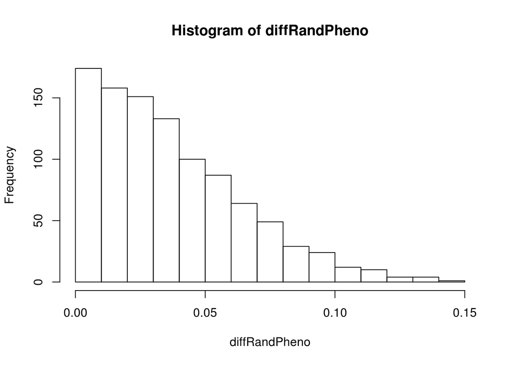

```r
hist(diffRandPheno)
```

```r
sum(diffRandPheno > trueDiff)/nPerm
```

```
## [1] 0.056
```

## Compare With Permuted Phenotype and Covariate Data

An more accurate depiction of randomly assigning individuals may to be permuted the covariates and HMGCR genotype together with the phenotype.

```r
#Segregate Sample Randomly (along with covariates and HMGCR score)
nPerm <- 1000
diffRandAllVar <- rep(NaN,nPerm)
permFit1 <- list()
permFit2 <- list()
for(i in 1:nPerm){
  randSeg <- sample(homoRef,size = length(homoRef),replace = F)
  permFit1[[i]] <- summary(lm(formula = 'LDL ~ HMGCR + sex + ages + bmi + PC1 + PC2 +PC3 + PC4 + PC5',data = cbind(data.frame(LDL = trainingSetData$phenotypes[randSeg],HMGCR = trainingSetData$dosageTarget[randSeg]),trainingSetData$covariates[randSeg,])))
  permFit2[[i]] <- summary(lm(formula = 'LDL ~ HMGCR + sex + ages + bmi + PC1 + PC2 +PC3 + PC4 + PC5',data = cbind(data.frame(LDL = trainingSetData$phenotypes[!randSeg],HMGCR = trainingSetData$dosageTarget[!randSeg]),trainingSetData$covariates[!randSeg,])))
  diffRandAllVar[i] <- abs(permFit1[[i]]$coefficients['HMGCR','Estimate'] - permFit2[[i]]$coefficients['HMGCR','Estimate'])
}
```

We check an example as to how the HMGCR score varies around two randomly assigned groups.

```r
permFit1[[1]]
```

```
##
## Call:
## lm(formula = "LDL ~ HMGCR + sex + ages + bmi + PC1 + PC2 +PC3 + PC4 + PC5",
##     data = cbind(data.frame(LDL = trainingSetData$phenotypes[randSeg],
##         HMGCR = trainingSetData$dosageTarget[randSeg]), trainingSetData$covariates[randSeg,
##         ]))
##
## Residuals:
##     Min      1Q  Median      3Q     Max
## -3.3140 -0.5661 -0.0546  0.5050  5.9916
##
## Coefficients:
##               Estimate Std. Error t value Pr(>|t|)
## (Intercept)  2.7505945  0.0280752  97.972  < 2e-16 ***
## HMGCR       -0.3340316  0.0254065 -13.147  < 2e-16 ***
## sex         -0.0972650  0.0058024 -16.763  < 2e-16 ***
## ages         0.0125900  0.0003605  34.925  < 2e-16 ***
## bmi          0.0148803  0.0006087  24.445  < 2e-16 ***
## PC1          0.6307045  0.1714147   3.679 0.000234 ***
## PC2          0.2391138  0.2042651   1.171 0.241761
## PC3         -0.3180876  0.2727800  -1.166 0.243579
## PC4         -0.0385643  0.3207367  -0.120 0.904296
## PC5          0.1612935  0.3216197   0.502 0.616018
## ---
## Signif. codes:  0 '***' 0.001 '**' 0.01 '*' 0.05 '.' 0.1 ' ' 1
##
## Residual standard error: 0.8217 on 81532 degrees of freedom
## Multiple R-squared:  0.02751,    Adjusted R-squared:  0.0274
## F-statistic: 256.2 on 9 and 81532 DF,  p-value: < 2.2e-16
```

```r
permFit2[[1]]
```

```
##
## Call:
## lm(formula = "LDL ~ HMGCR + sex + ages + bmi + PC1 + PC2 +PC3 + PC4 + PC5",
##     data = cbind(data.frame(LDL = trainingSetData$phenotypes[!randSeg],
##         HMGCR = trainingSetData$dosageTarget[!randSeg]), trainingSetData$covariates[!randSeg,
##         ]))
##
## Residuals:
##     Min      1Q  Median      3Q     Max
## -2.6686 -0.5641 -0.0528  0.4985  5.1305
##
## Coefficients:
##               Estimate Std. Error t value Pr(>|t|)
## (Intercept)  2.7252411  0.0431753  63.120  < 2e-16 ***
## HMGCR       -0.2896799  0.0388483  -7.457 9.08e-14 ***
## sex         -0.0947742  0.0089055 -10.642  < 2e-16 ***
## ages         0.0128995  0.0005545  23.262  < 2e-16 ***
## bmi          0.0143455  0.0009298  15.429  < 2e-16 ***
## PC1          0.2471257  0.2635196   0.938    0.348
## PC2         -0.0970386  0.3132319  -0.310    0.757
## PC3          0.0837563  0.4255856   0.197    0.844
## PC4          0.2207780  0.4988873   0.443    0.658
## PC5         -0.2066381  0.5063552  -0.408    0.683
## ---
## Signif. codes:  0 '***' 0.001 '**' 0.01 '*' 0.05 '.' 0.1 ' ' 1
##
## Residual standard error: 0.8232 on 34658 degrees of freedom
## Multiple R-squared:  0.02676,    Adjusted R-squared:  0.0265
## F-statistic: 105.9 on 9 and 34658 DF,  p-value: < 2.2e-16
```

We plot the distribution of the differences between two groups, and calculated a p-value for the true difference

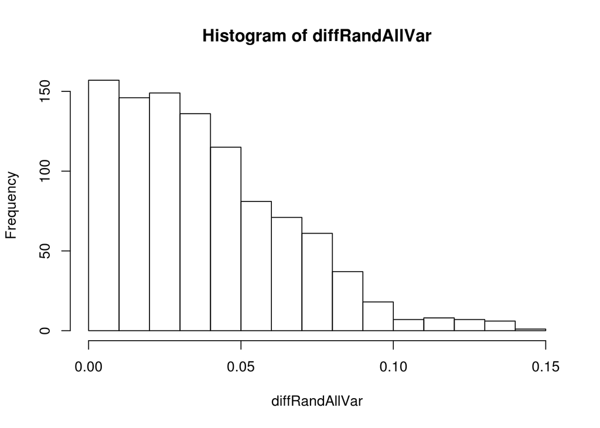

```r
hist(diffRandAllVar)
```

```r
sum(diffRandAllVar > trueDiff)/nPerm
```

```
## [1] 0.049
```